# Commuter Friction Survey – Descriptive Data Analysis

Group Project – Data Analysis and Preparation of Reports

2026-11-24

# 0. Checking the stress score (do this first)

The stress score is built from three questions (C1–C3). Before using it, check that (a) the three questions measure the same thing (**reliability**, Cronbach’s alpha) and (b) the score agrees with a separate stress question, C4 (**convergent validity**, Spearman correlation).

## 0.1 Reliability: Cronbach’s alpha

Cronbach’s alpha shows how consistently the three items move together. It runs from 0 to 1:

| Alpha | Reliability |
| --- | --- |
| 0.90 or above | Excellent |
| 0.80 – 0.89 | Good |
| 0.70 – 0.79 | Acceptable |
| 0.60 – 0.69 | Questionable |
| Below 0.60 | Poor |

The guide’s cut-off is **alpha ≥ 0.70**. “Alpha if item deleted” shows what alpha would be without each item. If removing an item makes alpha clearly higher, that item does not fit well with the others.

| Measure | Number of items | Alpha |
| --- | --- | --- |
| Cronbach’s alpha (C1–C3) | 3 | 0.845 |

| Item | Item-total correlation | Alpha if item deleted |
| --- | --- | --- |
| C1 Stressed – relaxed | 0.749 | 0.749 |
| C2 Worried – confident | 0.726 | 0.773 |
| C3 Hurried – calm | 0.665 | 0.829 |

Cronbach’s alpha = **0.845**.

Cronbach’s alpha for the three stress items (C1–C3) is 0.845, which indicates good internal consistency and is above the 0.70 cut-off given in the guide. Each item correlates strongly with the total of the other two (item–total correlations from 0.665 to 0.749), and removing any one item would lower alpha (to between 0.749 and 0.829). The three items therefore measure one underlying construct, and it is appropriate to combine them into a single stress score.

## 0.2 Convergent validity: Spearman correlation with C4

C4 (“Do you feel this kind of stress these days?”) is coded 1 = Not at all to 5 = Very much. A significant **positive** correlation (p < 0.05) means students with higher stress scores also report more stress in C4, so the score reflects real stress.

| Variables | Spearman’s rho | p-value | n |
| --- | --- | --- | --- |
| Stress score vs C4 (stress these days) | 0.196 | 0.024 | 132 |

The stress score has a positive and statistically significant Spearman correlation with C4 (ρ = 0.196, p = 0.024, n = 132). Students with higher commute stress scores also tend to report more stress in general, which supports the convergent validity of the score. The correlation is weak, which is expected, because C1–C3 refer specifically to the commute while C4 asks about stress in daily life as a whole.

# 1. Composition of the sample

## 1.1 One qualitative variable

Each graph is saved in the **figures** folder as a 300 dpi PNG file.

### 1.1.1 Respondent profile

#### Days per week travelling to university

| Days per week travelling to university | Count | Percentage |
| --- | --- | --- |
| 3–4 days | 70 | 53.03 |
| 5 days or more | 62 | 46.97 |
| Total | 132 | 100.00 |

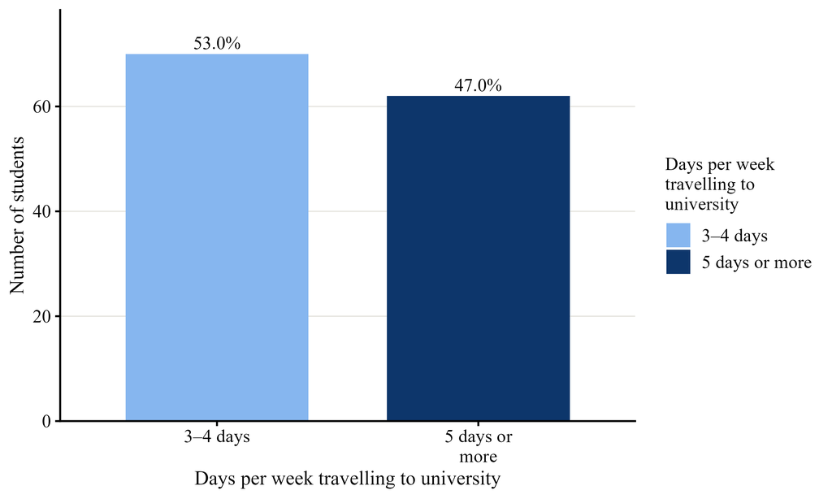

Slightly more than half of the students (53.03%, 70 students) travel to the university 3–4 days a week, while 46.97% (62 students) travel 5 days or more. Almost half of the sample therefore commutes on every working day, so commute conditions are a regular part of their week.

#### Faculty

| Faculty | Count | Percentage |
| --- | --- | --- |
| Applied Sciences | 66 | 50.00 |
| Management & Commerce | 17 | 12.88 |
| Engineering | 15 | 11.36 |
| Computing | 11 | 8.33 |
| Technology | 9 | 6.82 |
| Other faculties | 14 | 10.61 |
| Total | 132 | 100.00 |

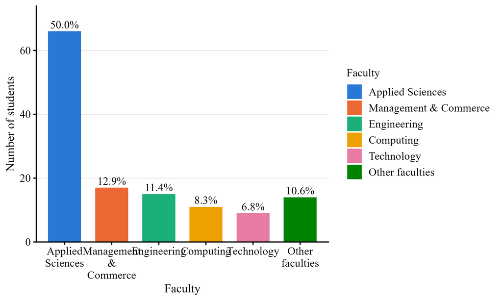

Half of the respondents (50.00%, 66 students) are from the Faculty of Applied Sciences. Management & Commerce (12.88%) and Engineering (11.36%) are the next largest groups, followed by Computing (8.33%) and Technology (6.82%), while the remaining faculties together account for 10.61%. The sample is therefore dominated by Applied Sciences students, which should be kept in mind when generalising the results to all undergraduates.

#### Year of study

| Year of study | Count | Percentage |
| --- | --- | --- |
| 1st year | 10 | 7.58 |
| 2nd year | 29 | 21.97 |
| 3rd year | 75 | 56.82 |
| 4th year | 16 | 12.12 |
| 5th year or above | 2 | 1.52 |
| Total | 132 | 100.00 |

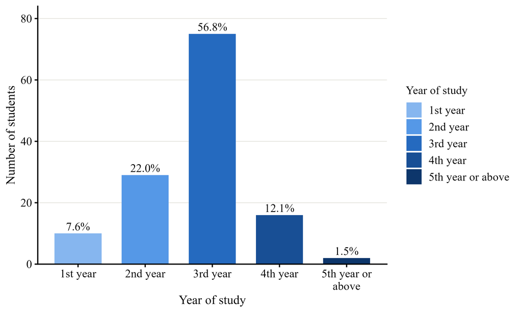

Third-year students form the majority of the sample (56.82%, 75 students), followed by second-year (21.97%) and fourth-year students (12.12%). First-year students (7.58%) and students in their fifth year or above (1.52%) are few. The results therefore mainly reflect the experience of students in the middle of their degree.

#### Gender

| Gender | Count | Percentage |
| --- | --- | --- |
| Male | 71 | 53.79 |
| Female | 61 | 46.21 |
| Total | 132 | 100.00 |

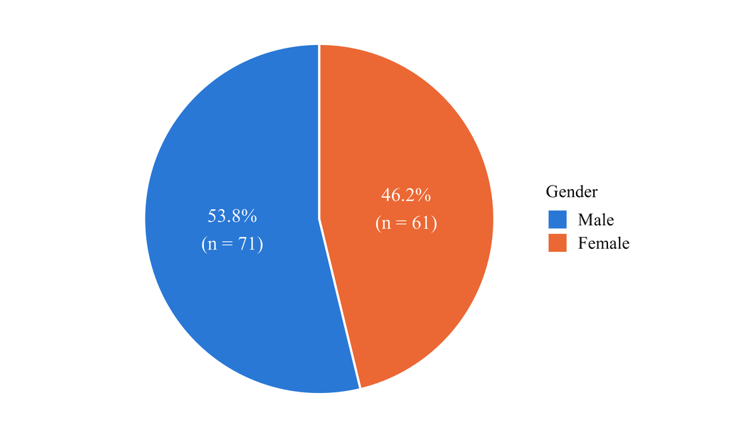

The sample is fairly balanced by gender: 53.79% (71) of the respondents are male and 46.21% (61) are female.

#### Residence during semester

| Residence during semester | Count | Percentage |
| --- | --- | --- |
| Home | 103 | 78.03 |
| Boarding place | 20 | 15.15 |
| University hostel | 8 | 6.06 |
| Other (please specify) | 1 | 0.76 |
| Total | 132 | 100.00 |

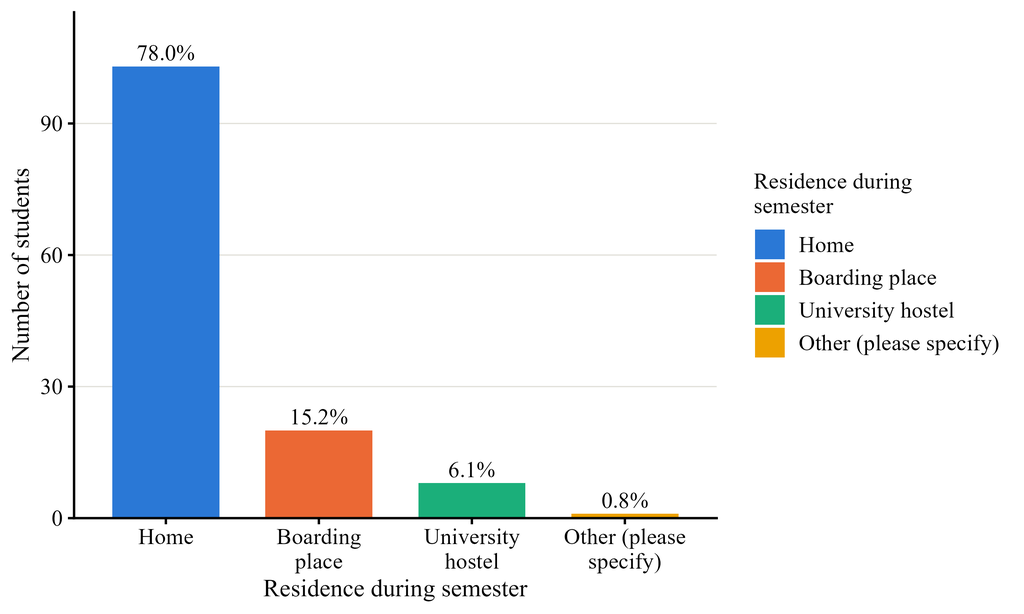

### 1.1.2 Travel characteristics

#### One-way distance to university

| One-way distance to university | Count | Percentage |
| --- | --- | --- |
| Less than 5 km | 36 | 27.27 |
| 5–14 km | 39 | 29.55 |
| 15–29 km | 44 | 33.33 |
| 30–49 km | 12 | 9.09 |
| 50 km or more | 1 | 0.76 |
| Total | 132 | 100.00 |

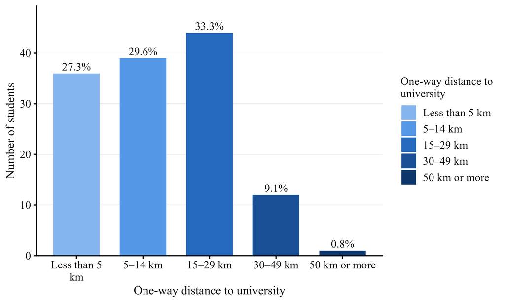

One-way distances are spread fairly evenly across the first three groups: 27.27% of students live less than 5 km from the university, 29.55% live 5–14 km away and 33.33% live 15–29 km away. Only 9.09% travel 30–49 km and a single student (0.76%) travels 50 km or more. In total, 43.18% of students travel 15 km or more each way.

#### Main transport mode

| Main transport mode | Count | Percentage |
| --- | --- | --- |
| Bus | 73 | 55.30 |
| Private vehicle | 27 | 20.45 |
| Walk or bicycle | 18 | 13.64 |
| Three-wheeler / taxi | 8 | 6.06 |
| Train | 6 | 4.55 |
| Total | 132 | 100.00 |

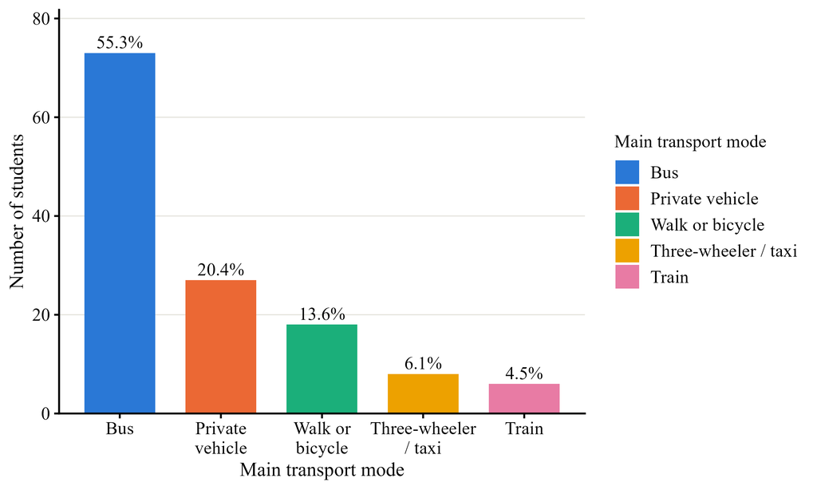

The bus is by far the most common main mode of transport, used by more than half of the students (55.30%, 73). Private vehicles come second (20.45%), followed by walking or cycling (13.64%), three-wheelers or taxis (6.06%) and the train (4.55%). Public transport (bus and train) therefore carries 59.85% of the sample.

#### Number of vehicle changes

| Number of vehicle changes | Count | Percentage |
| --- | --- | --- |
| No change | 62 | 46.97 |
| 1 change | 35 | 26.52 |
| 2 changes | 26 | 19.70 |
| 3 or more changes | 9 | 6.82 |
| Total | 132 | 100.00 |

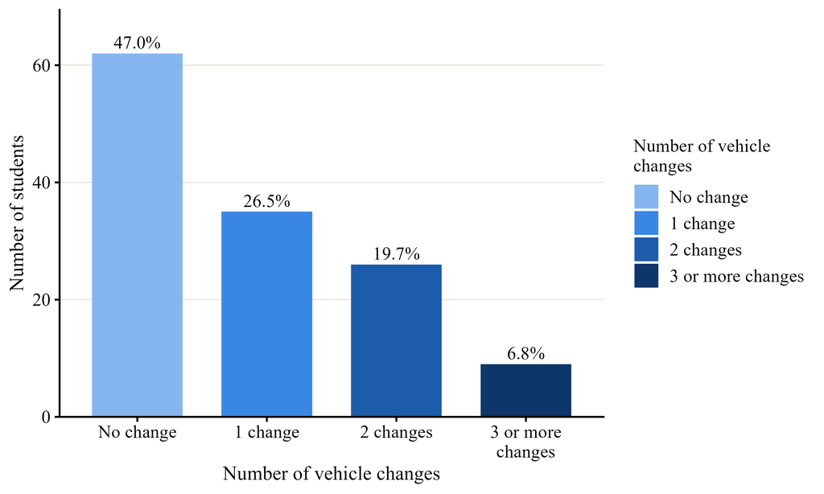

Nearly half of the students (46.97%) reach the university without changing vehicles. However, 26.52% change once, 19.70% change twice and 6.82% change three or more times, so more than half (53.03%) make at least one transfer on the way to the university.

#### Mode from home to main vehicle

| Mode from home to main vehicle | Count | Percentage |
| --- | --- | --- |
| Walk | 59 | 44.70 |
| Direct access | 44 | 33.33 |
| Dropped by someone | 14 | 10.61 |
| Three-wheeler | 10 | 7.58 |
| Bus | 5 | 3.79 |
| Total | 132 | 100.00 |

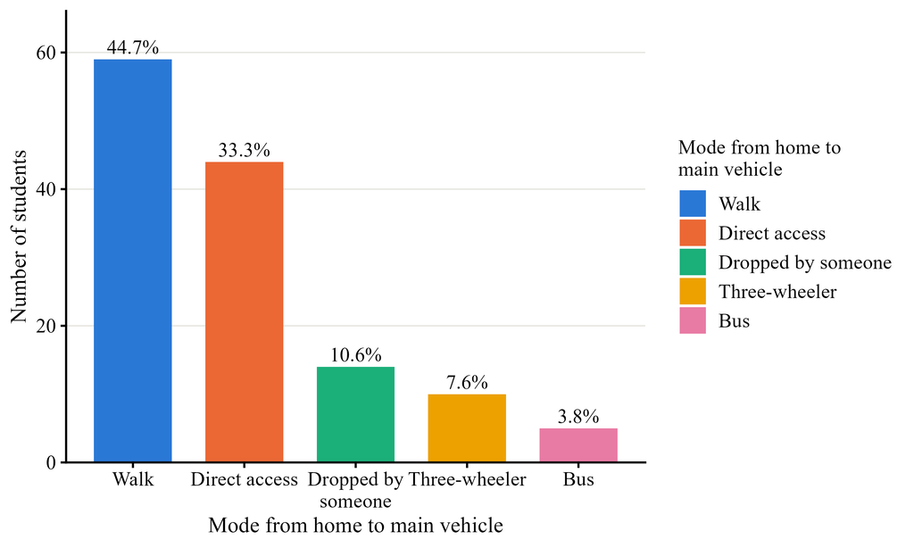

To reach their main vehicle, 44.70% of the students walk and 33.33% have direct access (they board their main transport at home). Smaller groups are dropped off by someone (10.61%), use a three-wheeler (7.58%) or take a bus (3.79%). Walking is therefore the main way of reaching the main vehicle.

#### Mode from main vehicle to university gate

| Mode from main vehicle to university gate | Count | Percentage |
| --- | --- | --- |
| Walk | 64 | 48.48 |
| Direct drop-off | 44 | 33.33 |
| Three-wheeler | 22 | 16.67 |
| Bus | 2 | 1.52 |
| Total | 132 | 100.00 |

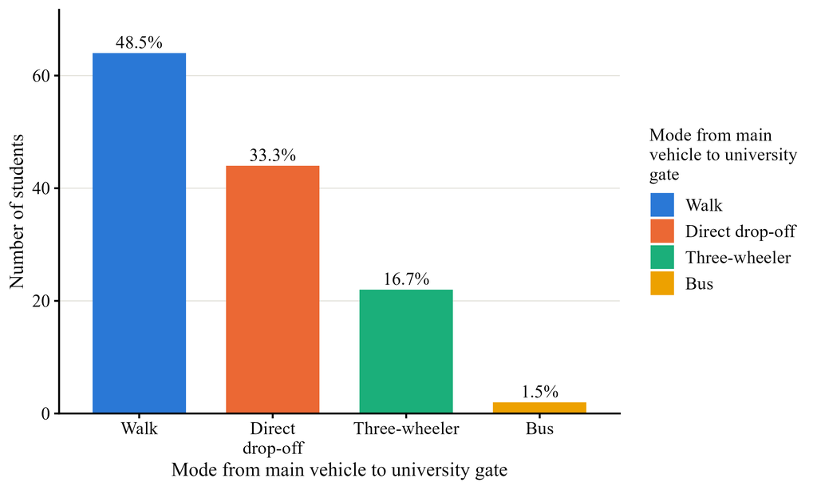

From the main vehicle to the university gate, almost half of the students walk (48.48%) and one-third are dropped directly at the gate (33.33%). A further 16.67% take a three-wheeler for the last stretch, while only 1.52% use a bus.

#### Seat availability

| Seat availability | Count | Percentage |
| --- | --- | --- |
| Get a seat | 61 | 46.21 |
| Not applicable | 38 | 28.79 |
| Stand | 33 | 25.00 |
| Total | 132 | 100.00 |

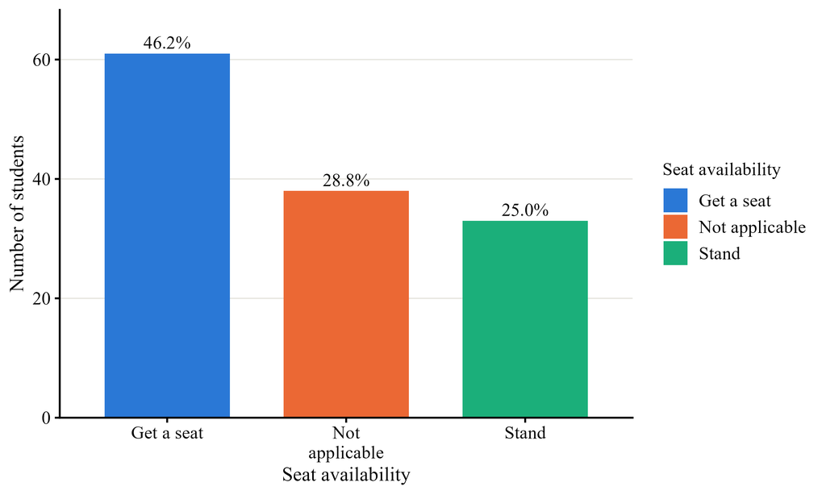

Among all respondents, 46.21% usually get a seat and 25.00% usually stand, while 28.79% answered ‘not applicable’ (mainly those who walk, cycle or use a private vehicle). Among the 94 students for whom the question applies, about one in three (35.1%) usually has to stand.

#### Late arrivals (15+ minutes)

| Late arrivals (15+ minutes) | Count | Percentage |
| --- | --- | --- |
| Never | 47 | 35.61 |
| 1 day/week | 45 | 34.09 |
| 2–3 days/week | 37 | 28.03 |
| 4+ days/week | 3 | 2.27 |
| Total | 132 | 100.00 |

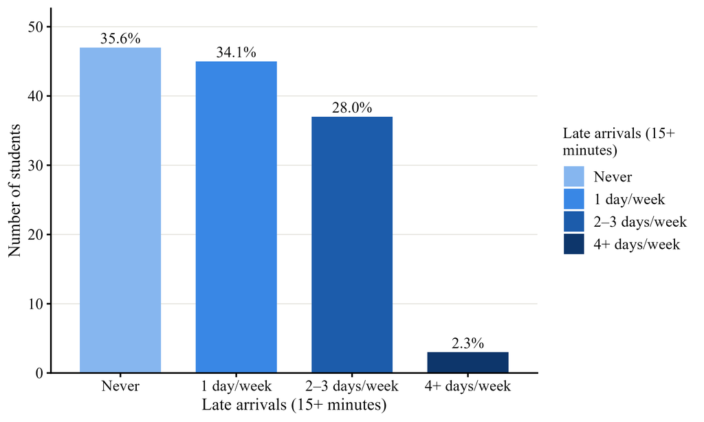

Just over one-third of the students (35.61%) never arrive 15 or more minutes late, while 34.09% are late one day a week and 28.03% two to three days a week. Very few (2.27%) are late four or more days a week. Overall, almost two-thirds of the students (64.39%) arrive late at least once a week.

#### One-way trip time

| One-way trip time | Count | Percentage |
| --- | --- | --- |
| Under 30 min | 44 | 33.33 |
| 30–59 min | 35 | 26.52 |
| 1 to 1½ hours | 24 | 18.18 |
| 1½ to 2 hours | 23 | 17.42 |
| Over 2 hours | 6 | 4.55 |
| Total | 132 | 100.00 |

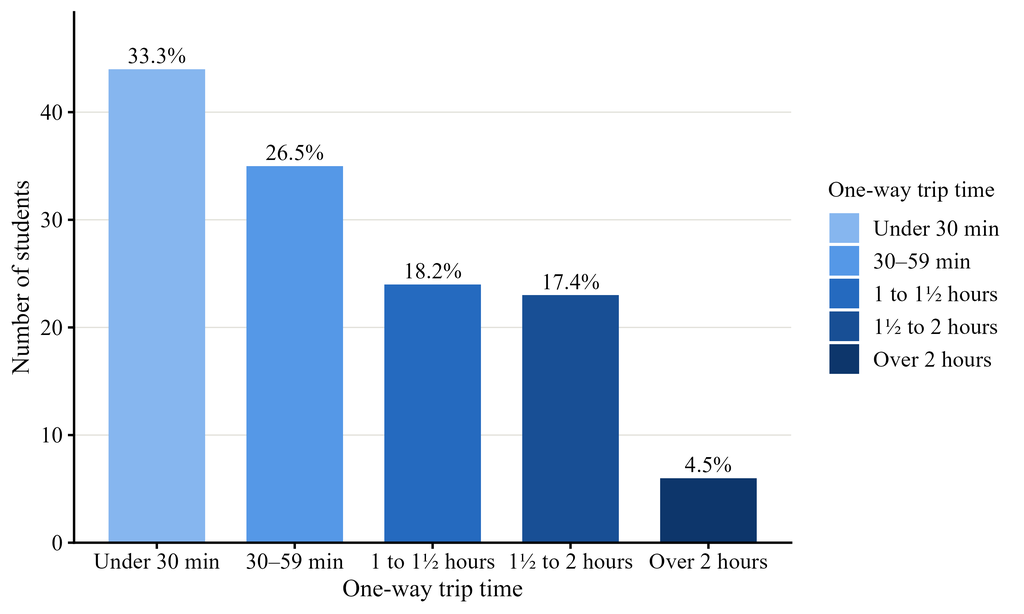

One-third of the students (33.33%) reach the university in under 30 minutes and 26.52% take 30–59 minutes. However, 40.15% spend an hour or more on a one-way trip: 18.18% take 1 to 1½ hours, 17.42% take 1½ to 2 hours and 4.55% take over 2 hours.

#### Waiting time for vehicle

| Waiting time for vehicle | Count | Percentage |
| --- | --- | --- |
| I don’t wait | 43 | 32.58 |
| Under 5 min | 25 | 18.94 |
| 5–15 min | 48 | 36.36 |
| 15–30 min | 15 | 11.36 |
| Over 30 min | 1 | 0.76 |
| Total | 132 | 100.00 |

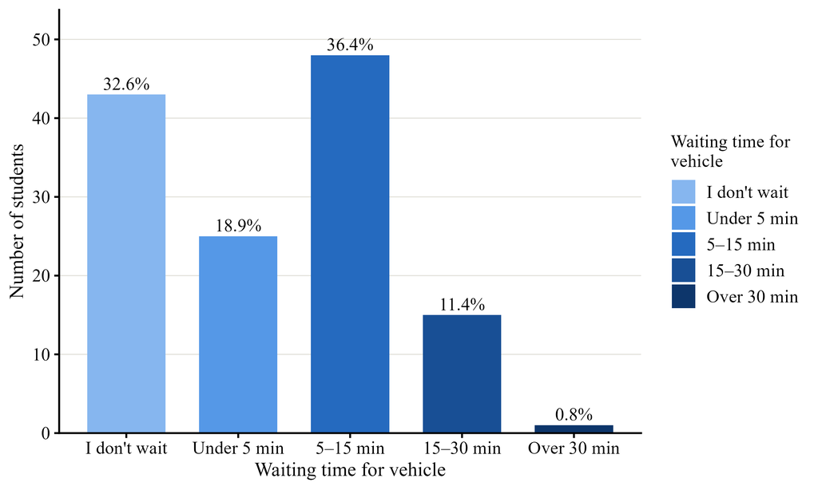

The most common waiting time for a vehicle is 5–15 minutes (36.36%). About one-third of the students (32.58%) do not wait at all and 18.94% wait less than 5 minutes. A smaller group waits 15–30 minutes (11.36%) and one student (0.76%) waits over 30 minutes.

#### Departure time

| Departure time | Count | Percentage |
| --- | --- | --- |
| Before 6:00 am | 15 | 11.36 |
| 6:00–6:59 am | 51 | 38.64 |
| 7:00–7:59 am | 52 | 39.39 |
| 8:00 am or later | 14 | 10.61 |
| Total | 132 | 100.00 |

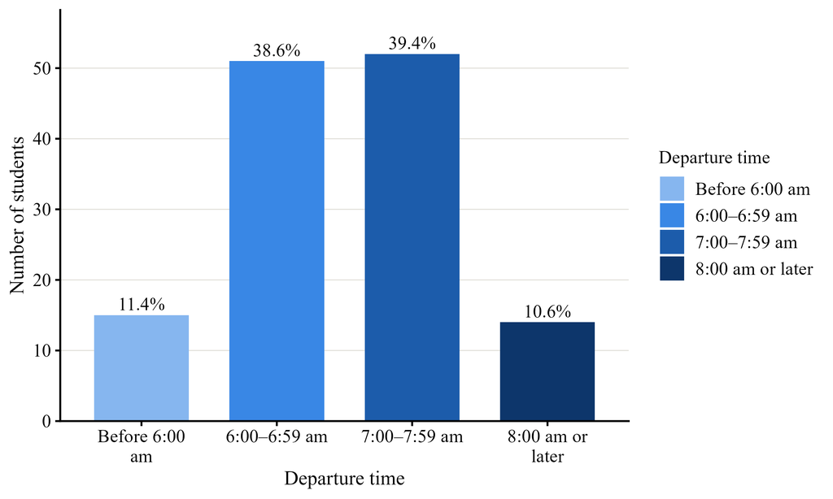

Most students leave for the university between 6:00 and 7:59 am (38.64% between 6:00 and 6:59 am and 39.39% between 7:00 and 7:59 am). About one in nine (11.36%) leave before 6:00 am, while 10.61% leave at 8:00 am or later.

#### Share of daily budget spent on travel

| Share of daily budget spent on travel | Count | Percentage |
| --- | --- | --- |
| Nothing (0%) | 22 | 16.67 |
| Less than 10% | 20 | 15.15 |
| 10%–25% | 36 | 27.27 |
| 26%–50% | 30 | 22.73 |
| More than 50% | 24 | 18.18 |
| Total | 132 | 100.00 |

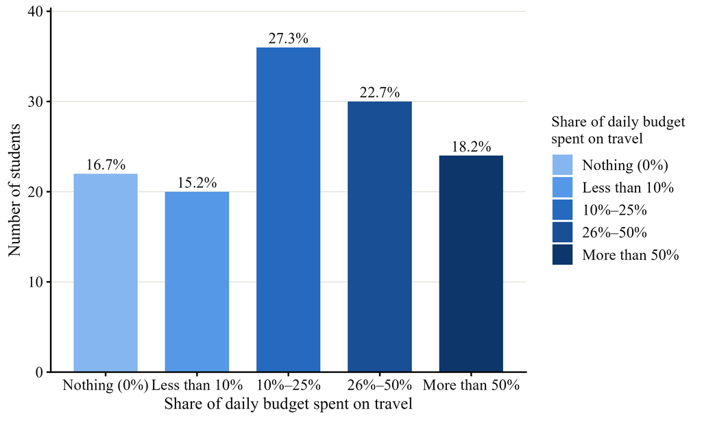

The share of the daily budget spent on travel varies widely. The largest group spends 10%–25% (27.27%), followed by 26%–50% (22.73%). Notably, 18.18% of students spend more than half of their daily budget on travel, whereas 16.67% spend nothing (mostly students living within 5 km of the university) and 15.15% spend less than 10%.

#### How often students feel unsafe

| How often students feel unsafe | Count | Percentage |
| --- | --- | --- |
| Never | 36 | 27.27 |
| Rarely | 47 | 35.61 |
| Sometimes | 40 | 30.30 |
| Often | 9 | 6.82 |
| Total | 132 | 100.00 |

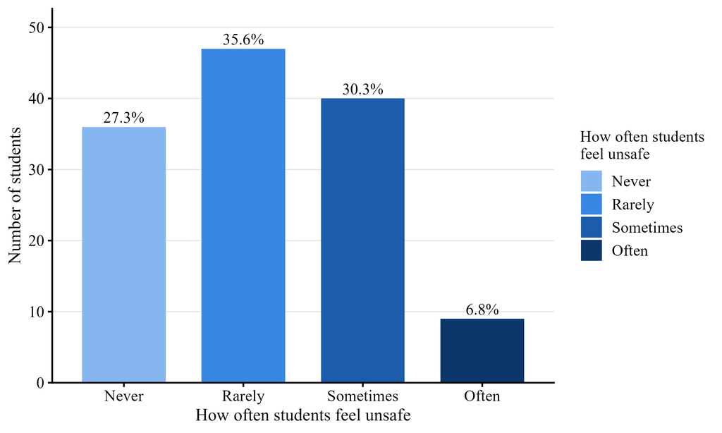

Most students rarely (35.61%) or never (27.27%) feel unsafe while commuting. However, 30.30% sometimes feel unsafe and 6.82% often do, so 37.12% of students feel unsafe at least some of the time.

### 1.1.3 Commute experience and wellbeing

#### C1 Stressed – relaxed

| Stressed (-3) to relaxed (+3) | Count | Percentage |
| --- | --- | --- |
| -3 Very stressed | 4 | 3.03 |
| -2 Quite stressed | 26 | 19.70 |
| -1 Slightly stressed | 39 | 29.55 |
| 0 Neither | 28 | 21.21 |
| +1 Slightly relaxed | 16 | 12.12 |
| +2 Quite relaxed | 11 | 8.33 |
| +3 Very relaxed | 8 | 6.06 |
| Total | 132 | 100.00 |

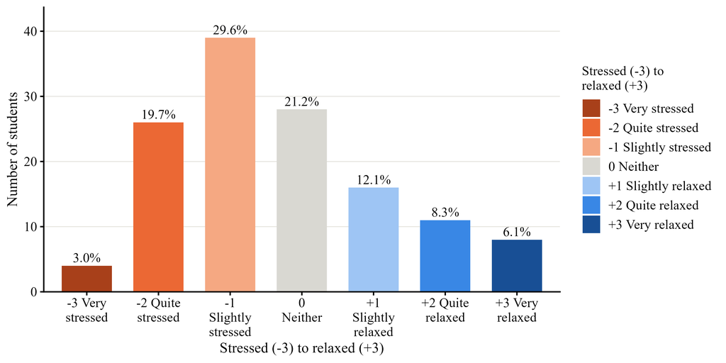

Responses lean towards the stressed side of the scale. About half of the students (52.27%) felt at least slightly stressed during the commute (−1 to −3), compared with 26.52% who felt relaxed (+1 to +3) and 21.21% who felt neither. The most common answer was ‘slightly stressed’ (29.55%).

#### C2 Worried – confident

| Worried (-3) to confident (+3) | Count | Percentage |
| --- | --- | --- |
| -3 Very worried | 3 | 2.27 |
| -2 Quite worried | 17 | 12.88 |
| -1 Slightly worried | 32 | 24.24 |
| 0 Neither | 42 | 31.82 |
| +1 Slightly confident | 18 | 13.64 |
| +2 Quite confident | 14 | 10.61 |
| +3 Very confident | 6 | 4.55 |
| Total | 132 | 100.00 |

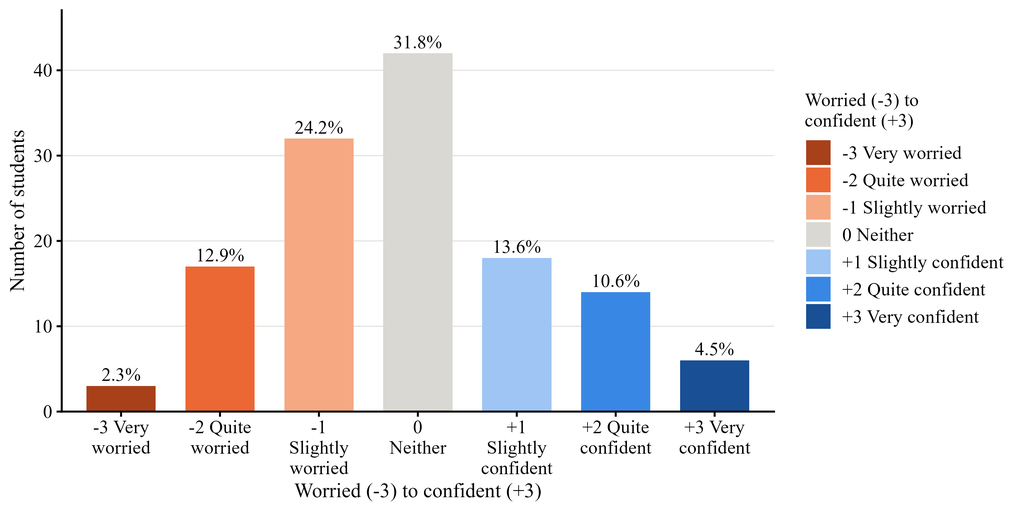

The most common response was neutral (31.82%). Still, 39.39% of students felt at least slightly worried, compared with 28.79% who felt confident. The distribution is therefore centred near the middle of the scale, with a moderate lean towards worry.

#### C3 Hurried – calm

| Hurried (-3) to calm (+3) | Count | Percentage |
| --- | --- | --- |
| -3 Very hurried | 9 | 6.82 |
| -2 Quite hurried | 28 | 21.21 |
| -1 Slightly hurried | 40 | 30.30 |
| 0 Neither | 27 | 20.45 |
| +1 Slightly calm | 16 | 12.12 |
| +2 Quite calm | 7 | 5.30 |
| +3 Very calm | 5 | 3.79 |
| Total | 132 | 100.00 |

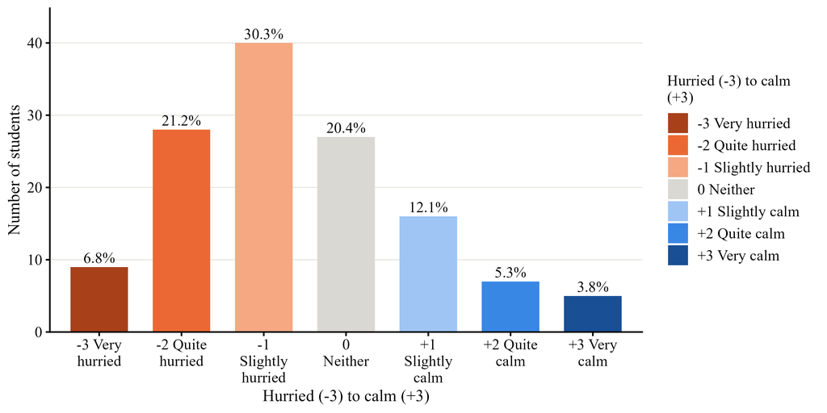

This item leans most strongly to the negative side of the three: 58.33% of students felt at least slightly hurried, while only 21.21% felt calm and 20.45% felt neither. ‘Slightly hurried’ was the most frequent answer (30.30%).

#### C4 Stress felt these days

| Stress felt these days | Count | Percentage |
| --- | --- | --- |
| Not at all | 24 | 18.18 |
| Only a little | 51 | 38.64 |
| To some extent | 45 | 34.09 |
| Rather much | 9 | 6.82 |
| Very much | 3 | 2.27 |
| Total | 132 | 100.00 |

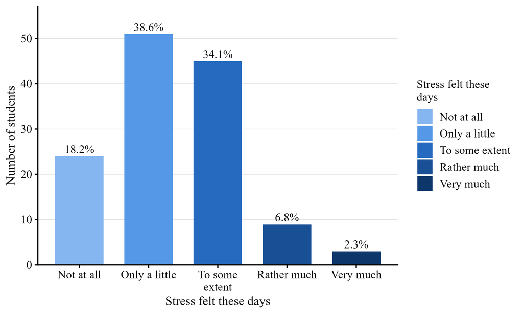

Most students report low to moderate general stress: 38.64% feel stressed ‘only a little’ and 34.09% ‘to some extent’. Only 9.09% feel stressed ‘rather much’ or ‘very much’, while 18.18% do not feel stressed at all.

#### Sleep quality last night

| Sleep quality last night | Count | Percentage |
| --- | --- | --- |
| Very poor | 5 | 3.79 |
| Poor | 27 | 20.45 |
| Average | 56 | 42.42 |
| Good | 35 | 26.52 |
| Very good | 9 | 6.82 |
| Total | 132 | 100.00 |

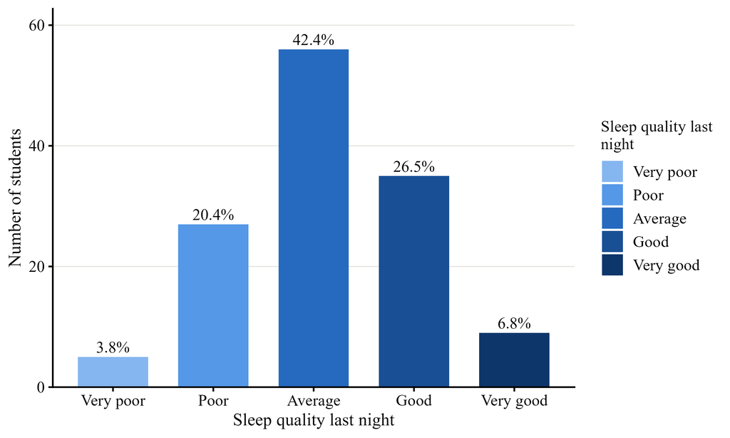

Sleep quality on the previous night was most often average (42.42%). One-third of the students (33.33%) slept well (good or very good), while 24.24% slept poorly (poor or very poor).

#### Academic workload pressure

| Academic workload pressure | Count | Percentage |
| --- | --- | --- |
| Very low | 2 | 1.52 |
| Low | 12 | 9.09 |
| Moderate | 64 | 48.48 |
| High | 36 | 27.27 |
| Very high | 18 | 13.64 |
| Total | 132 | 100.00 |

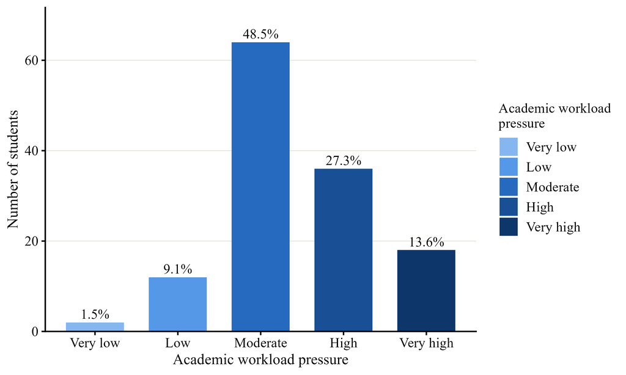

Almost half of the students (48.48%) rated their academic workload pressure as moderate. A substantial 40.91% rated it high or very high, while only 10.61% rated it low or very low.

#### Crowding on bus/train

Only bus and train users answered this question; blanks are excluded.

| Crowding on bus/train | Count | Percentage |
| --- | --- | --- |
| Not crowded | 3 | 3.80 |
| Slightly crowded | 17 | 21.52 |
| Moderately crowded | 24 | 30.38 |
| Very crowded | 30 | 37.97 |
| Extremely crowded | 5 | 6.33 |
| Total | 79 | 100.00 |

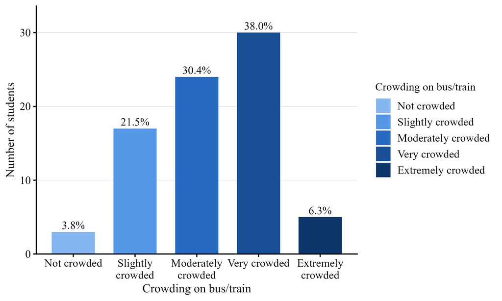

Of the 79 bus and train users, 37.97% described their vehicle as very crowded and 6.33% as extremely crowded, so 44.30% travelled in heavily crowded conditions. A further 30.38% reported moderate crowding (all seats taken), while only 25.32% found the vehicle not or slightly crowded.

#### Weather made commute harder

| Weather made commute harder | Count | Percentage |
| --- | --- | --- |
| Not at all | 19 | 14.39 |
| Slightly | 33 | 25.00 |
| Moderately | 39 | 29.55 |
| Very much | 26 | 19.70 |
| Extremely | 15 | 11.36 |
| Total | 132 | 100.00 |

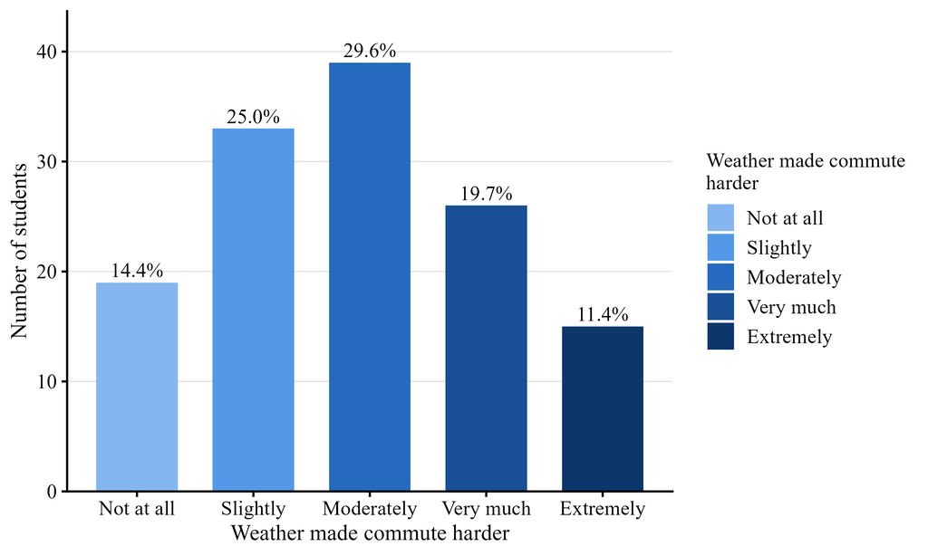

Weather made the commute harder for most students: 29.55% said it made the commute moderately harder, 19.70% very much harder and 11.36% extremely harder. Only 14.39% said the weather did not make the commute harder at all.

#### Stress level

| Stress level | Count | Percentage |
| --- | --- | --- |
| Low | 15 | 11.36 |
| Moderate | 85 | 64.39 |
| High | 32 | 24.24 |
| Total | 132 | 100.00 |

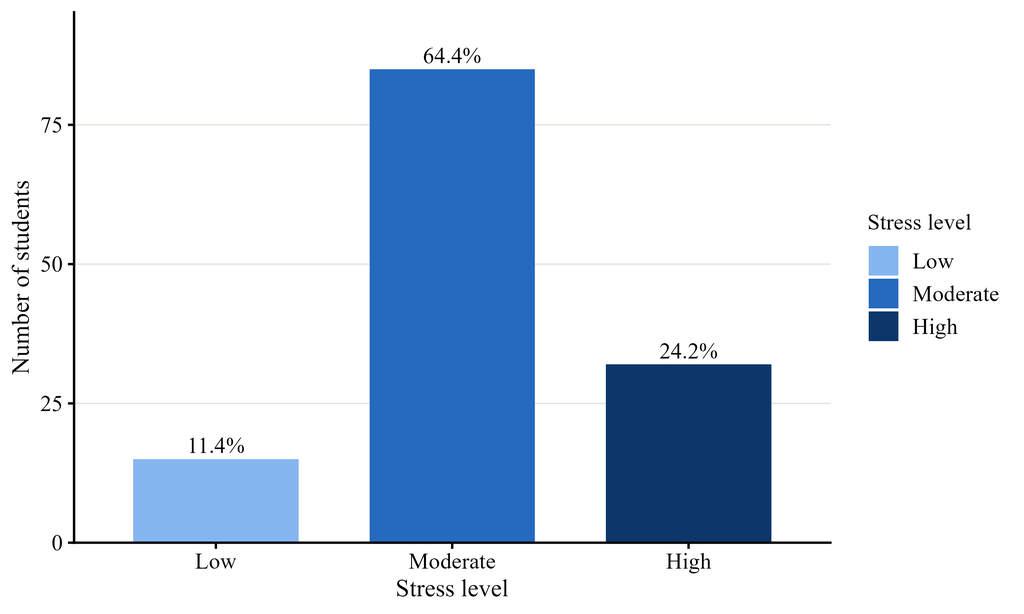

Based on the commute stress score, most students (64.39%, 85) are at a moderate stress level. Almost a quarter (24.24%, 32) are highly stressed, while only 11.36% (15) have low stress. Highly stressed students therefore outnumber low-stress students by about two to one.

## 1.2 Two qualitative variables

### 1.2.1 Stress level compared with other variables

#### Stress level by gender

|  | Gender | Low | Moderate | High | Total |
| --- | --- | --- | --- | --- | --- |
| Male | Male | 12 (16.9%) | 46 (64.8%) | 13 (18.3%) | 71 (100%) |
| Female | Female | 3 (4.9%) | 39 (63.9%) | 19 (31.1%) | 61 (100%) |
| 3 | Total | 15 (11.4%) | 85 (64.4%) | 32 (24.2%) | 132 (100%) |

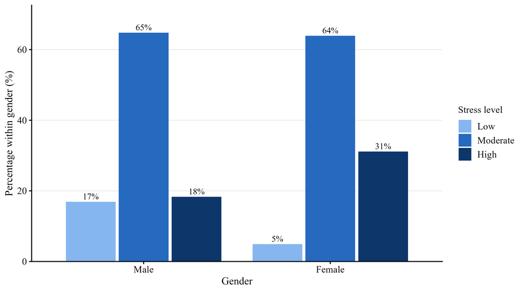

Female students show higher commute stress than male students. 31.1% of female students are at the high stress level, compared with 18.3% of male students, while low stress is much more common among males (16.9%) than females (4.9%). The share at the moderate level is almost identical for both groups (64.8% and 63.9%).

#### Stress level by one-way distance to university

|  | One-way distance to university | Low | Moderate | High | Total |
| --- | --- | --- | --- | --- | --- |
| Less than 5 km | Less than 5 km | 8 (22.2%) | 24 (66.7%) | 4 (11.1%) | 36 (100%) |
| 5–14 km | 5–14 km | 5 (12.8%) | 26 (66.7%) | 8 (20.5%) | 39 (100%) |
| 15–29 km | 15–29 km | 2 (4.5%) | 27 (61.4%) | 15 (34.1%) | 44 (100%) |
| 30 km or more | 30 km or more | 0 (0.0%) | 8 (61.5%) | 5 (38.5%) | 13 (100%) |
| 5 | Total | 15 (11.4%) | 85 (64.4%) | 32 (24.2%) | 132 (100%) |

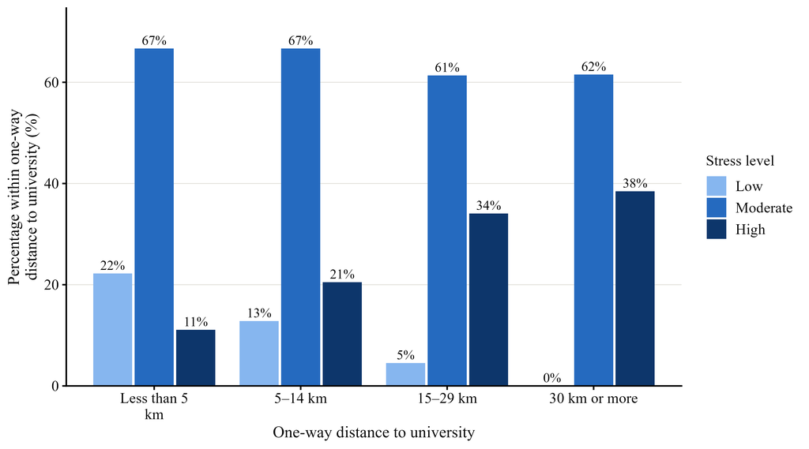

Stress rises steadily with distance. The share of highly stressed students increases from 11.1% among those living less than 5 km away to 20.5% (5–14 km), 34.1% (15–29 km) and 38.5% (30 km or more). At the same time, the share with low stress falls from 22.2% to 0.0%. Living further from the university is therefore associated with higher commute stress.

#### Stress level by main transport mode

|  | Main transport mode | Low | Moderate | High | Total |
| --- | --- | --- | --- | --- | --- |
| Bus | Bus | 1 (1.4%) | 48 (65.8%) | 24 (32.9%) | 73 (100%) |
| Private vehicle | Private vehicle | 9 (33.3%) | 16 (59.3%) | 2 (7.4%) | 27 (100%) |
| Walk or bicycle | Walk or bicycle | 3 (16.7%) | 14 (77.8%) | 1 (5.6%) | 18 (100%) |
| Three-wheeler / taxi | Three-wheeler / taxi | 2 (25.0%) | 4 (50.0%) | 2 (25.0%) | 8 (100%) |
| Train | Train | 0 (0.0%) | 3 (50.0%) | 3 (50.0%) | 6 (100%) |
| 6 | Total | 15 (11.4%) | 85 (64.4%) | 32 (24.2%) | 132 (100%) |

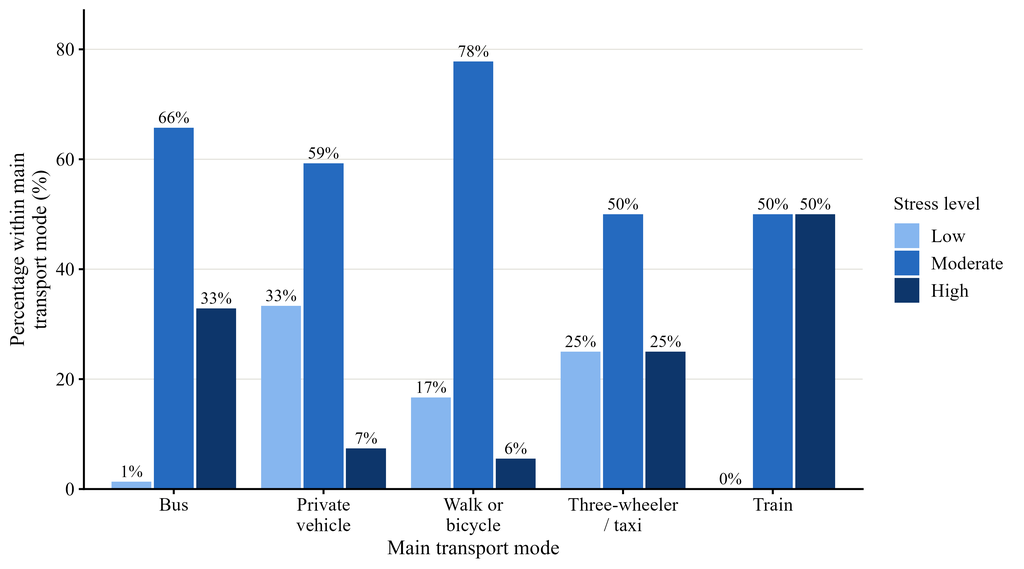

Stress differs clearly by main mode. Train (50.0%) and bus users (32.9%) have the highest shares of high stress, whereas only 7.4% of private-vehicle users and 5.6% of those who walk or cycle are highly stressed. Low stress is most common among private-vehicle users (33.3%) and almost absent among bus users (1.4%). Only 6 students use the train and 8 use three-wheelers or taxis, so the percentages for these groups should be interpreted with caution.

#### Stress level by mode from home to main vehicle

|  | Mode from home to main vehicle | Low | Moderate | High | Total |
| --- | --- | --- | --- | --- | --- |
| Walk | Walk | 2 (3.4%) | 38 (64.4%) | 19 (32.2%) | 59 (100%) |
| Direct access | Direct access | 11 (25.0%) | 29 (65.9%) | 4 (9.1%) | 44 (100%) |
| Dropped by someone | Dropped by someone | 1 (7.1%) | 7 (50.0%) | 6 (42.9%) | 14 (100%) |
| Three-wheeler | Three-wheeler | 0 (0.0%) | 7 (70.0%) | 3 (30.0%) | 10 (100%) |
| Bus | Bus | 1 (20.0%) | 4 (80.0%) | 0 (0.0%) | 5 (100%) |
| 6 | Total | 15 (11.4%) | 85 (64.4%) | 32 (24.2%) | 132 (100%) |

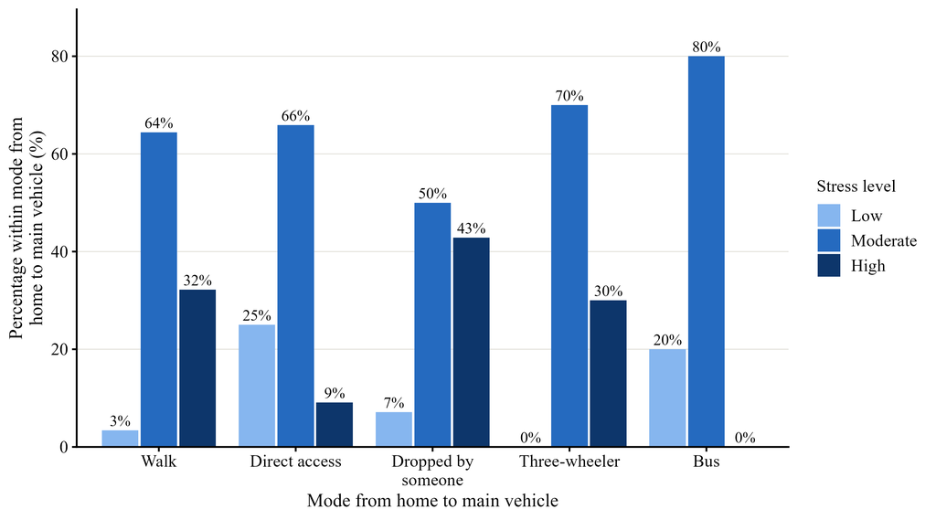

Students with direct access to their main vehicle have the lowest stress: only 9.1% are highly stressed and 25.0% have low stress. High stress is more common among those dropped off by someone (42.9%), those who walk to their main vehicle (32.2%) and those who take a three-wheeler (30.0%). The direct-access group consists mainly of private-vehicle users and students who walk or cycle the whole way, which helps explain its lower stress.

#### Stress level by mode from main vehicle to university gate

|  | Mode from main vehicle to university gate | Low | Moderate | High | Total |
| --- | --- | --- | --- | --- | --- |
| Walk | Walk | 3 (4.7%) | 42 (65.6%) | 19 (29.7%) | 64 (100%) |
| Direct drop-off | Direct drop-off | 11 (25.0%) | 30 (68.2%) | 3 (6.8%) | 44 (100%) |
| Three-wheeler | Three-wheeler | 1 (4.5%) | 13 (59.1%) | 8 (36.4%) | 22 (100%) |
| Bus | Bus | 0 (0.0%) | 0 (0.0%) | 2 (100.0%) | 2 (100%) |
| 5 | Total | 15 (11.4%) | 85 (64.4%) | 32 (24.2%) | 132 (100%) |

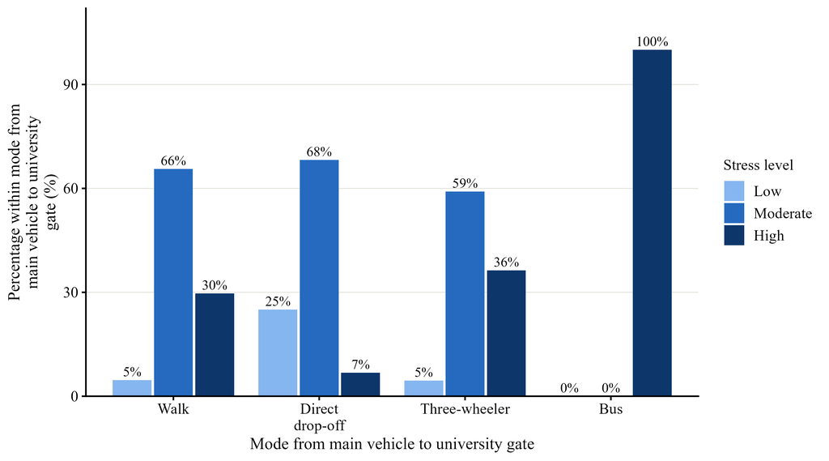

A similar pattern appears for the last stretch to the gate. Students dropped directly at the gate have the lowest stress (6.8% high, 25.0% low), while 36.4% of those taking a three-wheeler and 29.7% of those walking from their vehicle are highly stressed. Both students who take a bus for the last stretch are highly stressed, but this group is too small (n = 2) to draw conclusions.

#### Stress level by seat availability

|  | Seat availability | Low | Moderate | High | Total |
| --- | --- | --- | --- | --- | --- |
| Get a seat | Get a seat | 6 (9.8%) | 37 (60.7%) | 18 (29.5%) | 61 (100%) |
| Not applicable | Not applicable | 9 (23.7%) | 26 (68.4%) | 3 (7.9%) | 38 (100%) |
| Stand | Stand | 0 (0.0%) | 22 (66.7%) | 11 (33.3%) | 33 (100%) |
| 4 | Total | 15 (11.4%) | 85 (64.4%) | 32 (24.2%) | 132 (100%) |

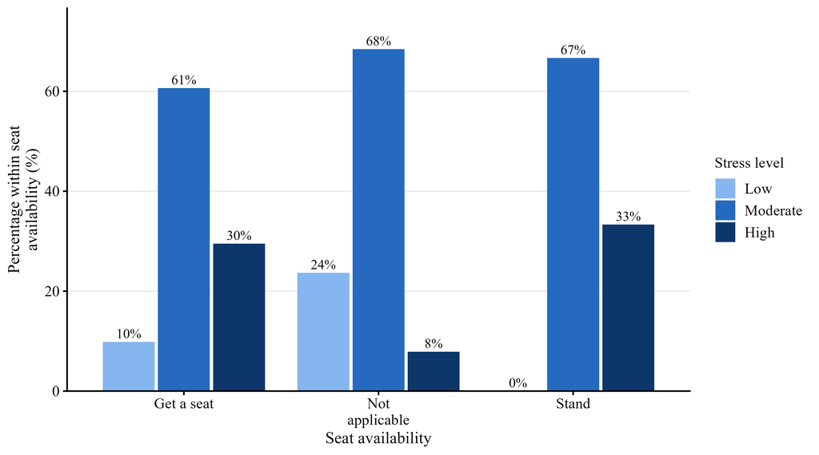

Students for whom a seat is not applicable (mainly those who walk, cycle or travel by private vehicle) have the lowest stress (7.9% high, 23.7% low). Among public-transport users, the share of highly stressed students is similar for those who usually stand (33.3%) and those who usually get a seat (29.5%), although no student who stands has low stress. Getting a seat therefore does not, by itself, protect students from high stress.